# Erosive disturbance

### Calculating national and regional indices

We can calculate national and region-wise medians and 0.25 and 0.75 quantiles. Calculating means is not recommended since these data do not follow a Gaussian distribution. The national and regional estimates are computed separately (i.e. regional estimates are not spatially aggregated)

```r
## forest ecosystems
# list to hold the results
NO_SLIT_003_2022to2024 <- data.frame(
  Indicator = "erosion",
  region = c("Norway", "Northern.Norway", "Central.Norway", "Western.Norway", "Eastern.Norway", "Southern.Norway"),
  median = NA,
  low = NA,
  high = NA,
  n = NA
)
NO_SLIT_003_2019to2021 <- data.frame(
  Indicator = "erosion",
  region = c("Norway", "Northern.Norway", "Central.Norway", "Western.Norway", "Eastern.Norway", "Southern.Norway"),
  median = NA,
  low = NA,
  high = NA,
  n = NA
)

# calculation of the median and quantiles
myQuantiles <- c(.25, .5, .75)
# Norway 2022-2024
df <- res.ANO.slit[(res.ANO.slit$hovedoekosystem_250m2=='skog' | res.ANO.slit$hovedoekosystem_rute=='Forest') & res.ANO.slit$aar %in% c(2022, 2023, 2024) ,c('ano_flate_id','region','hovedoekosystem_250m2','hovedoekosystem_rute','erosion')]
res <-  quantile(df$erosion,myQuantiles, na.rm=T)
NO_SLIT_003_2022to2024$low[1] <- res[1]
NO_SLIT_003_2022to2024$median[1] <- res[2]
NO_SLIT_003_2022to2024$high[1] <- res[3]
NO_SLIT_003_2022to2024$n[1] <- nrow(df[!is.na(df$erosion),])
# regions 2022-2024
for (i in 2:6) {
  df <- res.ANO.slit[(res.ANO.slit$hovedoekosystem_250m2=='skog' | res.ANO.slit$hovedoekosystem_rute=='Forest') & res.ANO.slit$aar %in% c(2022, 2023, 2024) & res.ANO.slit$region==NO_SLIT_003_2022to2024$region[i], c('ano_flate_id','region','hovedoekosystem_250m2','hovedoekosystem_rute','erosion')]
res <-  quantile(df$erosion,myQuantiles, na.rm=T)
NO_SLIT_003_2022to2024$low[i] <- res[1]
NO_SLIT_003_2022to2024$median[i] <- res[2]
NO_SLIT_003_2022to2024$high[i] <- res[3]
NO_SLIT_003_2022to2024$n[i] <- nrow(df[!is.na(df$erosion),])
}
# Norway 2019-2021
df <- res.ANO.slit[(res.ANO.slit$hovedoekosystem_250m2=='skog' | res.ANO.slit$hovedoekosystem_rute=='Forest') & res.ANO.slit$aar %in% c(2019, 2020, 2021) ,c('ano_flate_id','region','hovedoekosystem_250m2','hovedoekosystem_rute','erosion')]
res <-  quantile(df$erosion,myQuantiles, na.rm=T)
NO_SLIT_003_2019to2021$low[1] <- res[1]
NO_SLIT_003_2019to2021$median[1] <- res[2]
NO_SLIT_003_2019to2021$high[1] <- res[3]
NO_SLIT_003_2019to2021$n[1] <- nrow(df[!is.na(df$erosion),])
# regions 2019-2021
for (i in 2:6) {
  df <- res.ANO.slit[(res.ANO.slit$hovedoekosystem_250m2=='skog' | res.ANO.slit$hovedoekosystem_rute=='Forest') & res.ANO.slit$aar %in% c(2019, 2020, 2021) & res.ANO.slit$region==NO_SLIT_003_2019to2021$region[i], c('ano_flate_id','region','hovedoekosystem_250m2','hovedoekosystem_rute','erosion')]
res <-  quantile(df$erosion,myQuantiles, na.rm=T)
NO_SLIT_003_2019to2021$low[i] <- res[1]
NO_SLIT_003_2019to2021$median[i] <- res[2]
NO_SLIT_003_2019to2021$high[i] <- res[3]
NO_SLIT_003_2019to2021$n[i] <- nrow(df[!is.na(df$erosion),])
}


## mountain ecosystems
# list to hold the results
NO_SLIT_001_2022to2024 <- data.frame(
  Indicator = "erosion",
  region = c("Norway", "Northern.Norway", "Central.Norway", "Western.Norway", "Eastern.Norway", "Southern.Norway"),
  median = NA,
  low = NA,
  high = NA,
  n = NA
)
NO_SLIT_001_2019to2021 <- data.frame(
  Indicator = "erosion",
  region = c("Norway", "Northern.Norway", "Central.Norway", "Western.Norway", "Eastern.Norway", "Southern.Norway"),
  median = NA,
  low = NA,
  high = NA,
  n = NA
)

# calculation of the median and quantiles
# Norway 2022-2024
df <- res.ANO.slit[(res.ANO.slit$hovedoekosystem_250m2=='fjell' | res.ANO.slit$hovedoekosystem_rute=='Mountain') & res.ANO.slit$aar %in% c(2022, 2023, 2024) ,c('ano_flate_id','region','hovedoekosystem_250m2','hovedoekosystem_rute','erosion')]
res <-  quantile(df$erosion,myQuantiles, na.rm=T)
NO_SLIT_001_2022to2024$low[1] <- res[1]
NO_SLIT_001_2022to2024$median[1] <- res[2]
NO_SLIT_001_2022to2024$high[1] <- res[3]
NO_SLIT_001_2022to2024$n[1] <- nrow(df[!is.na(df$erosion),])
# regions 2022-2024
for (i in 2:6) {
  df <- res.ANO.slit[(res.ANO.slit$hovedoekosystem_250m2=='fjell' | res.ANO.slit$hovedoekosystem_rute=='Mountain') & res.ANO.slit$aar %in% c(2022, 2023, 2024) & res.ANO.slit$region==NO_SLIT_001_2022to2024$region[i], c('ano_flate_id','region','hovedoekosystem_250m2','hovedoekosystem_rute','erosion')]
res <-  quantile(df$erosion,myQuantiles, na.rm=T)
NO_SLIT_001_2022to2024$low[i] <- res[1]
NO_SLIT_001_2022to2024$median[i] <- res[2]
NO_SLIT_001_2022to2024$high[i] <- res[3]
NO_SLIT_001_2022to2024$n[i] <- nrow(df[!is.na(df$erosion),])
}
# Norway 2019-2021
df <- res.ANO.slit[(res.ANO.slit$hovedoekosystem_250m2=='fjell' | res.ANO.slit$hovedoekosystem_rute=='Mountain') & res.ANO.slit$aar %in% c(2019, 2020, 2021) ,c('ano_flate_id','region','hovedoekosystem_250m2','hovedoekosystem_rute','erosion')]
res <-  quantile(df$erosion,myQuantiles, na.rm=T)
NO_SLIT_001_2019to2021$low[1] <- res[1]
NO_SLIT_001_2019to2021$median[1] <- res[2]
NO_SLIT_001_2019to2021$high[1] <- res[3]
NO_SLIT_001_2019to2021$n[1] <- nrow(df[!is.na(df$erosion),])
# regions 2019-2021
for (i in 2:6) {
  df <- res.ANO.slit[(res.ANO.slit$hovedoekosystem_250m2=='fjell' | res.ANO.slit$hovedoekosystem_rute=='Mountain') & res.ANO.slit$aar %in% c(2019, 2020, 2021) & res.ANO.slit$region==NO_SLIT_001_2019to2021$region[i], c('ano_flate_id','region','hovedoekosystem_250m2','hovedoekosystem_rute','erosion')]
res <-  quantile(df$erosion,myQuantiles, na.rm=T)
NO_SLIT_001_2019to2021$low[i] <- res[1]
NO_SLIT_001_2019to2021$median[i] <- res[2]
NO_SLIT_001_2019to2021$high[i] <- res[3]
NO_SLIT_001_2019to2021$n[i] <- nrow(df[!is.na(df$erosion),])
}

## wetland ecosystems
# list to hold the results
NO_SLIT_002_2022to2024 <- data.frame(
  Indicator = "erosion",
  region = c("Norway", "Northern.Norway", "Central.Norway", "Western.Norway", "Eastern.Norway", "Southern.Norway"),
  median = NA,
  low = NA,
  high = NA,
  n = NA
)
NO_SLIT_002_2019to2021 <- data.frame(
  Indicator = "erosion",
  region = c("Norway", "Northern.Norway", "Central.Norway", "Western.Norway", "Eastern.Norway", "Southern.Norway"),
  median = NA,
  low = NA,
  high = NA,
  n = NA
)

# calculation of the median and quantiles
# Norway 2022-2024
df <- res.ANO.slit[(res.ANO.slit$hovedoekosystem_250m2 == "vaatmark" | res.ANO.slit$hovedoekosystem_rute == "Wetland") & res.ANO.slit$aar %in% c(2019, 2020, 2021), c("ano_flate_id", "region", "hovedoekosystem_250m2", "hovedoekosystem_rute", "erosion")]
res <- quantile(df$erosion, myQuantiles, na.rm = T)
NO_SLIT_002_2022to2024$low[1] <- res[1]
NO_SLIT_002_2022to2024$median[1] <- res[2]
NO_SLIT_002_2022to2024$high[1] <- res[3]
NO_SLIT_002_2019to2021$n[1] <- nrow(df[!is.na(df$erosion), ])
# regions 2022-2024
for (i in 2:6) {
  df <- res.ANO.slit[(res.ANO.slit$hovedoekosystem_250m2 == "vaatmark" | res.ANO.slit$hovedoekosystem_rute == "Wetland") & res.ANO.slit$aar %in% c(2019, 2020, 2021) & res.ANO.slit$region == NO_SLIT_002_2019to2021$region[i], c("ano_flate_id", "region", "hovedoekosystem_250m2", "hovedoekosystem_rute", "erosion")]
  res <- quantile(df$erosion, myQuantiles, na.rm = T)
  NO_SLIT_002_2019to2021$low[i] <- res[1]
  NO_SLIT_002_2019to2021$median[i] <- res[2]
  NO_SLIT_002_2019to2021$high[i] <- res[3]
  NO_SLIT_002_2019to2021$n[i] <- nrow(df[!is.na(df$erosion), ])
}
# Norway 2019-2021
df <- res.ANO.slit[(res.ANO.slit$hovedoekosystem_250m2=='vaatmark' | res.ANO.slit$hovedoekosystem_rute=='Wetland') & res.ANO.slit$aar %in% c(2019, 2020, 2021) ,c('ano_flate_id','region','hovedoekosystem_250m2','hovedoekosystem_rute','erosion')]
res <-  quantile(df$erosion,myQuantiles, na.rm=T)
NO_SLIT_002_2019to2021$low[1] <- res[1]
NO_SLIT_002_2019to2021$median[1] <- res[2]
NO_SLIT_002_2019to2021$high[1] <- res[3]
NO_SLIT_002_2019to2021$n[1] <- nrow(df[!is.na(df$erosion),])
# regions 2019-2021
for (i in 2:6) {
  df <- res.ANO.slit[(res.ANO.slit$hovedoekosystem_250m2=='vaatmark' | res.ANO.slit$hovedoekosystem_rute=='Wetland') & res.ANO.slit$aar %in% c(2019, 2020, 2021) & res.ANO.slit$region==NO_SLIT_002_2019to2021$region[i], c('ano_flate_id','region','hovedoekosystem_250m2','hovedoekosystem_rute','erosion')]
res <-  quantile(df$erosion,myQuantiles, na.rm=T)
NO_SLIT_002_2019to2021$low[i] <- res[1]
NO_SLIT_002_2019to2021$median[i] <- res[2]
NO_SLIT_002_2019to2021$high[i] <- res[3]
NO_SLIT_002_2019to2021$n[i] <- nrow(df[!is.na(df$erosion),])
}
```

```r
## open lowland ecosystems
# list to hold the results
NO_SLIT_004_2022to2024 <- data.frame(
  Indicator = "erosion",
  region = c("Norway", "Northern.Norway", "Central.Norway", "Western.Norway", "Eastern.Norway", "Southern.Norway"),
  median = NA,
  low = NA,
  high = NA,
  n = NA
)
NO_SLIT_004_2019to2021 <- data.frame(
  Indicator = "erosion",
  region = c("Norway", "Northern.Norway", "Central.Norway", "Western.Norway", "Eastern.Norway", "Southern.Norway"),
  median = NA,
  low = NA,
  high = NA,
  n = NA
)

# calculation of the median and quantiles
# Norway 2022-2024
df <- res.ANO.slit[(res.ANO.slit$hovedoekosystem_250m2 %in% c("naturlig_apne", "semi_naturlig_mark") | res.ANO.slit$hovedoekosystem_rute %in% c("Seminat", "Natopen") | res.ANO.slit$hovedtype_rute %in% c("T40", "T41")) & res.ANO.slit$aar %in% c(2022, 2023, 2024), c("ano_flate_id", "region", "hovedoekosystem_250m2", "hovedoekosystem_rute", "erosion")]
res <- quantile(df$erosion, myQuantiles, na.rm = T)
NO_SLIT_004_2022to2024$low[1] <- res[1]
NO_SLIT_004_2022to2024$median[1] <- res[2]
NO_SLIT_004_2022to2024$high[1] <- res[3]
NO_SLIT_004_2022to2024$n[1] <- nrow(df[!is.na(df$erosion), ])
# regions 2022-2024
for (i in 2:6) {
  df <- res.ANO.slit[(res.ANO.slit$hovedoekosystem_250m2 %in% c("naturlig_apne", "semi_naturlig_mark") | res.ANO.slit$hovedoekosystem_rute %in% c("Seminat", "Natopen") | res.ANO.slit$hovedtype_rute %in% c("T40", "T41")) & res.ANO.slit$aar %in% c(2022, 2023, 2024) & res.ANO.slit$region == NO_SLIT_004_2022to2024$region[i], c("ano_flate_id", "region", "hovedoekosystem_250m2", "hovedoekosystem_rute", "erosion")]
  res <- quantile(df$erosion, myQuantiles, na.rm = T)
  NO_SLIT_004_2022to2024$low[i] <- res[1]
  NO_SLIT_004_2022to2024$median[i] <- res[2]
  NO_SLIT_004_2022to2024$high[i] <- res[3]
  NO_SLIT_004_2022to2024$n[i] <- nrow(df[!is.na(df$erosion), ])
}
# Norway 2019-2021
df <- res.ANO.slit[(res.ANO.slit$hovedoekosystem_250m2 %in% c("naturlig_apne", "semi_naturlig_mark") | res.ANO.slit$hovedoekosystem_rute %in% c("Seminat", "Natopen") | res.ANO.slit$hovedtype_rute %in% c("T40", "T41")) & res.ANO.slit$aar %in% c(2019, 2020, 2021), c("ano_flate_id", "region", "hovedoekosystem_250m2", "hovedoekosystem_rute", "erosion")]
res <- quantile(df$erosion, myQuantiles, na.rm = T)
NO_SLIT_004_2019to2021$low[1] <- res[1]
NO_SLIT_004_2019to2021$median[1] <- res[2]
NO_SLIT_004_2019to2021$high[1] <- res[3]
NO_SLIT_004_2019to2021$n[1] <- nrow(df[!is.na(df$erosion), ])
# regions 2019-2021
for (i in 2:6) {
  df <- res.ANO.slit[(res.ANO.slit$hovedoekosystem_250m2 %in% c("naturlig_apne", "semi_naturlig_mark") | res.ANO.slit$hovedoekosystem_rute %in% c("Seminat", "Natopen") | res.ANO.slit$hovedtype_rute %in% c("T40", "T41")) & res.ANO.slit$aar %in% c(2019, 2020, 2021) & res.ANO.slit$region == NO_SLIT_004_2019to2021$region[i], c("ano_flate_id", "region", "hovedoekosystem_250m2", "hovedoekosystem_rute", "erosion")]
  res <- quantile(df$erosion, myQuantiles, na.rm = T)
  NO_SLIT_004_2019to2021$low[i] <- res[1]
  NO_SLIT_004_2019to2021$median[i] <- res[2]
  NO_SLIT_004_2019to2021$high[i] <- res[3]
  NO_SLIT_004_2019to2021$n[i] <- nrow(df[!is.na(df$erosion), ])
}


## naturally open lowland ecosystems
# list to hold the results
NO_SLIT_004a_2022to2024 <- data.frame(
  Indicator = "erosion",
  region = c("Norway", "Northern.Norway", "Central.Norway", "Western.Norway", "Eastern.Norway", "Southern.Norway"),
  median = NA,
  low = NA,
  high = NA,
  n = NA
)
NO_SLIT_004a_2019to2021 <- data.frame(
  Indicator = "erosion",
  region = c("Norway", "Northern.Norway", "Central.Norway", "Western.Norway", "Eastern.Norway", "Southern.Norway"),
  median = NA,
  low = NA,
  high = NA,
  n = NA
)

# calculation of the median and quantiles
# Norway 2022-2024
df <- res.ANO.slit[(res.ANO.slit$hovedoekosystem_250m2 %in% c("naturlig_apne") | res.ANO.slit$hovedoekosystem_rute %in% c("Natopen")) & res.ANO.slit$aar %in% c(2022, 2023, 2024), c("ano_flate_id", "region", "hovedoekosystem_250m2", "hovedoekosystem_rute", "erosion")]
res <- quantile(df$erosion, myQuantiles, na.rm = T)
NO_SLIT_004a_2022to2024$low[1] <- res[1]
NO_SLIT_004a_2022to2024$median[1] <- res[2]
NO_SLIT_004a_2022to2024$high[1] <- res[3]
NO_SLIT_004a_2022to2024$n[1] <- nrow(df[!is.na(df$erosion), ])
# regions 2022-2024
for (i in 2:6) {
  df <- res.ANO.slit[(res.ANO.slit$hovedoekosystem_250m2 %in% c("naturlig_apne") | res.ANO.slit$hovedoekosystem_rute %in% c("Natopen")) & res.ANO.slit$aar %in% c(2022, 2023, 2024) & res.ANO.slit$region == NO_SLIT_004a_2022to2024$region[i], c("ano_flate_id", "region", "hovedoekosystem_250m2", "hovedoekosystem_rute", "erosion")]
  res <- quantile(df$erosion, myQuantiles, na.rm = T)
  NO_SLIT_004a_2022to2024$low[i] <- res[1]
  NO_SLIT_004a_2022to2024$median[i] <- res[2]
  NO_SLIT_004a_2022to2024$high[i] <- res[3]
  NO_SLIT_004a_2022to2024$n[i] <- nrow(df[!is.na(df$erosion), ])
}
# Norway 2019-2021
df <- res.ANO.slit[(res.ANO.slit$hovedoekosystem_250m2 %in% c("naturlig_apne") | res.ANO.slit$hovedoekosystem_rute %in% c("Natopen")) & res.ANO.slit$aar %in% c(2019, 2020, 2021), c("ano_flate_id", "region", "hovedoekosystem_250m2", "hovedoekosystem_rute", "erosion")]
res <- quantile(df$erosion, myQuantiles, na.rm = T)
NO_SLIT_004a_2019to2021$low[1] <- res[1]
NO_SLIT_004a_2019to2021$median[1] <- res[2]
NO_SLIT_004a_2019to2021$high[1] <- res[3]
NO_SLIT_004a_2019to2021$n[1] <- nrow(df[!is.na(df$erosion), ])
# regions 2019-2021
for (i in 2:6) {
  df <- res.ANO.slit[(res.ANO.slit$hovedoekosystem_250m2 %in% c("naturlig_apne") | res.ANO.slit$hovedoekosystem_rute %in% c("Natopen")) & res.ANO.slit$aar %in% c(2019, 2020, 2021) & res.ANO.slit$region == NO_SLIT_004a_2019to2021$region[i], c("ano_flate_id", "region", "hovedoekosystem_250m2", "hovedoekosystem_rute", "erosion")]
  res <- quantile(df$erosion, myQuantiles, na.rm = T)
  NO_SLIT_004a_2019to2021$low[i] <- res[1]
  NO_SLIT_004a_2019to2021$median[i] <- res[2]
  NO_SLIT_004a_2019to2021$high[i] <- res[3]
  NO_SLIT_004a_2019to2021$n[i] <- nrow(df[!is.na(df$erosion), ])
}
```

```r
## semi-natural ecosystems
# list to hold the results
NO_SLIT_004b_2022to2024 <- data.frame(
  Indicator = "erosion",
  region = c("Norway", "Northern.Norway", "Central.Norway", "Western.Norway", "Eastern.Norway", "Southern.Norway"),
  median = NA,
  low = NA,
  high = NA,
  n = NA
)
NO_SLIT_004b_2019to2021 <- data.frame(
  Indicator = "erosion",
  region = c("Norway", "Northern.Norway", "Central.Norway", "Western.Norway", "Eastern.Norway", "Southern.Norway"),
  median = NA,
  low = NA,
  high = NA,
  n = NA
)

# calculation of the median and quantiles
# Norway 2022-2024
df <- res.ANO.slit[(res.ANO.slit$hovedoekosystem_250m2 %in% c("semi_naturlig_mark") | res.ANO.slit$hovedoekosystem_rute %in% c("Seminat") | res.ANO.slit$hovedtype_rute %in% c("T40", "T41")) & res.ANO.slit$aar %in% c(2022, 2023, 2024), c("ano_flate_id", "region", "hovedoekosystem_250m2", "hovedoekosystem_rute", "erosion")]
res <- quantile(df$erosion, myQuantiles, na.rm = T)
NO_SLIT_004b_2022to2024$low[1] <- res[1]
NO_SLIT_004b_2022to2024$median[1] <- res[2]
NO_SLIT_004b_2022to2024$high[1] <- res[3]
NO_SLIT_004b_2022to2024$n[1] <- nrow(df[!is.na(df$erosion), ])
# regions 2022-2024
for (i in 2:6) {
  df <- res.ANO.slit[(res.ANO.slit$hovedoekosystem_250m2 %in% c("semi_naturlig_mark") | res.ANO.slit$hovedoekosystem_rute %in% c("Seminat") | res.ANO.slit$hovedtype_rute %in% c("T40", "T41")) & res.ANO.slit$aar %in% c(2022, 2023, 2024) & res.ANO.slit$region == NO_SLIT_004b_2022to2024$region[i], c("ano_flate_id", "region", "hovedoekosystem_250m2", "hovedoekosystem_rute", "erosion")]
  res <- quantile(df$erosion, myQuantiles, na.rm = T)
  NO_SLIT_004b_2022to2024$low[i] <- res[1]
  NO_SLIT_004b_2022to2024$median[i] <- res[2]
  NO_SLIT_004b_2022to2024$high[i] <- res[3]
  NO_SLIT_004b_2022to2024$n[i] <- nrow(df[!is.na(df$erosion), ])
}
# Norway 2019-2021
df <- res.ANO.slit[(res.ANO.slit$hovedoekosystem_250m2 %in% c("semi_naturlig_mark") | res.ANO.slit$hovedoekosystem_rute %in% c("Seminat") | res.ANO.slit$hovedtype_rute %in% c("T40", "T41")) & res.ANO.slit$aar %in% c(2019, 2020, 2021), c("ano_flate_id", "region", "hovedoekosystem_250m2", "hovedoekosystem_rute", "erosion")]
res <- quantile(df$erosion, myQuantiles, na.rm = T)
NO_SLIT_004b_2019to2021$low[1] <- res[1]
NO_SLIT_004b_2019to2021$median[1] <- res[2]
NO_SLIT_004b_2019to2021$high[1] <- res[3]
NO_SLIT_004b_2019to2021$n[1] <- nrow(df[!is.na(df$erosion), ])
# regions 2019-2021
for (i in 2:6) {
  df <- res.ANO.slit[(res.ANO.slit$hovedoekosystem_250m2 %in% c("naturlig_apne", "semi_naturlig_mark") | res.ANO.slit$hovedoekosystem_rute %in% c("Seminat", "Natopen") | res.ANO.slit$hovedtype_rute %in% c("T40", "T41")) & res.ANO.slit$aar %in% c(2019, 2020, 2021) & res.ANO.slit$region == NO_SLIT_004b_2019to2021$region[i], c("ano_flate_id", "region", "hovedoekosystem_250m2", "hovedoekosystem_rute", "erosion")]
  res <- quantile(df$erosion, myQuantiles, na.rm = T)
  NO_SLIT_004b_2019to2021$low[i] <- res[1]
  NO_SLIT_004b_2019to2021$median[i] <- res[2]
  NO_SLIT_004b_2019to2021$high[i] <- res[3]
  NO_SLIT_004b_2019to2021$n[i] <- nrow(df[!is.na(df$erosion), ])
}
```

## 10. Results

The results are shown in Table 2.

```r
### median indicator values for 'area without erosion plant species', lower and upper prediction intervals (low, high), and number of observations (n)
# open lowland (natopen & seminat combined)
bind_rows(
  NO_SLIT_004_2022to2024 |> mutate(Indicator = "NO_SLIT_004", years = "2022-2024", ecosystem = "Open lowland"),
  NO_SLIT_004_2019to2021 |> mutate(Indicator = "NO_SLIT_004", years = "2019-2021", ecosystem = "Open lowland"),
# natopen
  NO_SLIT_004a_2022to2024 |> mutate(Indicator = "NO_SLIT_004a", years = "2022-2024", ecosystem = "Naturally open ecosystems"),
  NO_SLIT_004a_2019to2021 |> mutate(Indicator = "NO_SLIT_004a", years = "2019-2021", ecosystem = "Naturally open ecosystems"),
# seminat
  NO_SLIT_004b_2022to2024 |> mutate(Indicator = "NO_SLIT_004b", years = "2022-2024", ecosystem = "Semi-natural ecosystems"),
  NO_SLIT_004b_2019to2021 |> mutate(Indicator = "NO_SLIT_004b", years = "2019-2021", ecosystem = "Semi-natural ecosystems"),
# mountain ecosystems
  NO_SLIT_001_2022to2024 |> mutate(Indicator = "NO_SLIT_001", years = "2022-2024", ecosystem = "Mountains"),
  NO_SLIT_001_2019to2021 |> mutate(Indicator = "NO_SLIT_001", years = "2019-2021", ecosystem = "Mountains"),
# wetland ecosystems
  NO_SLIT_002_2022to2024 |> mutate(Indicator = "NO_SLIT_002", years = "2022-2024", ecosystem = "Wetlands"),
  NO_SLIT_002_2019to2021 |> mutate(Indicator = "NO_SLIT_002", years = "2019-2021", ecosystem = "Wetlands"),
# forest ecosystems
  NO_SLIT_003_2022to2024 |> mutate(Indicator = "NO_SLIT_003", years = "2022-2024", ecosystem = "Forest"),
  NO_SLIT_003_2019to2021 |> mutate(Indicator = "NO_SLIT_003", years = "2019-2021", ecosystem = "Forest")
) |>
  # removing 'norway' from the name of the other regions so it's possible to filter the datatable
  mutate(region = str_remove(region, "\\.Norway$")) |>
  DT::datatable(filter = "top")
```

Table 2: Indicator values for the indicator Erosive disturbance.

|  | Indicator | region | median | low | high | n | years | ecosystem |
| --- | --- | --- | --- | --- | --- | --- | --- | --- |
| 1 | NO_SLIT_004 | Norway | 1 | 1 | 1 | 427 | 2022-2024 | Open lowland |
| 2 | NO_SLIT_004 | Northern | 1 | 1 | 1 | 130 | 2022-2024 | Open lowland |
| 3 | NO_SLIT_004 | Central | 1 | 1 | 1 | 54 | 2022-2024 | Open lowland |
| 4 | NO_SLIT_004 | Western | 1 | 1 | 1 | 126 | 2022-2024 | Open lowland |
| 5 | NO_SLIT_004 | Eastern | 1 | 1 | 1 | 50 | 2022-2024 | Open lowland |
| 6 | NO_SLIT_004 | Southern | 1 | 1 | 1 | 67 | 2022-2024 | Open lowland |
| 7 | NO_SLIT_004 | Norway | 1 | 1 | 1 | 358 | 2019-2021 | Open lowland |
| 8 | NO_SLIT_004 | Northern | 1 | 1 | 1 | 91 | 2019-2021 | Open lowland |
| 9 | NO_SLIT_004 | Central | 1 | 1 | 1 | 59 | 2019-2021 | Open lowland |
| 10 | NO_SLIT_004 | Western | 1 | 1 | 1 | 119 | 2019-2021 | Open lowland |

[output cut: 62 more lines]

The summary statistics indicate very good condition with respect to this indicator, but since the summary statistics hide all information below 1 here, wen can illustrate the occurrence of condition values below 1 with showing histograms

Across all ecosystem types, by period:

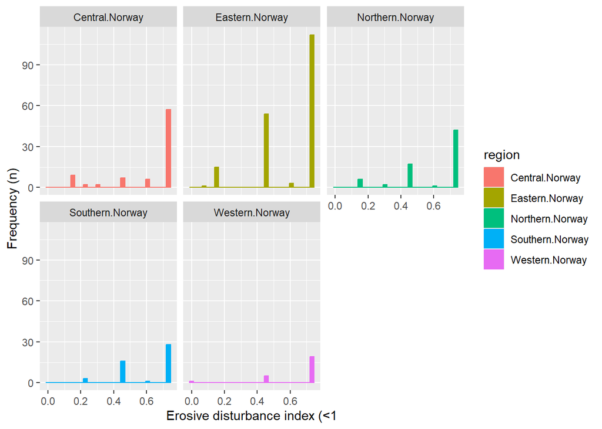

```r
# period 2019-2021
res.ANO.slit %>%
  filter(aar %in% c(2019, 2020, 2021)) %>%
  filter(erosion<0.99) %>%
  ggplot( aes(x=erosion, color=region, fill=region)) +
  geom_histogram() +
  xlab("Erosive disturbance index (<1") +
  ylab("Frequency (n)") +
  facet_wrap(~region)
```

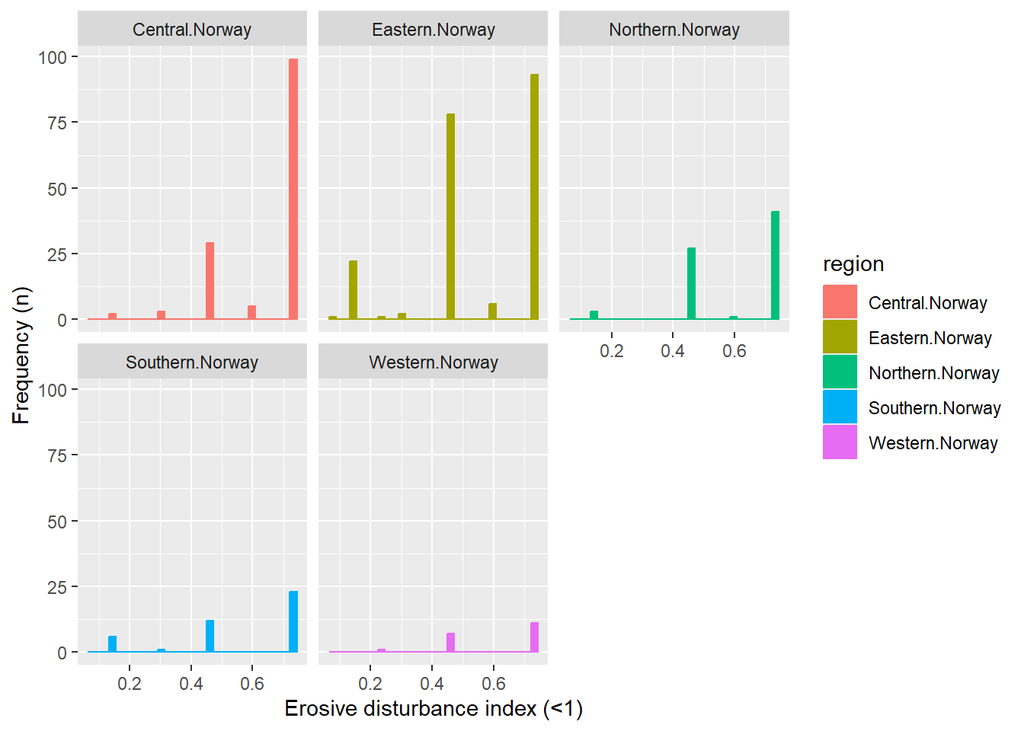

```r
# period 2022-2024
res.ANO.slit %>%
  filter(aar %in% c(2022, 2023, 2024)) %>%
  filter(erosion<0.99) %>%
  ggplot( aes(x=erosion, color=region, fill=region)) +
  geom_histogram() +
  xlab("Erosive disturbance index (<1)") +
  ylab("Frequency (n)") +
  facet_wrap(~region)
```

By ecosystem type (across both reporting periods):

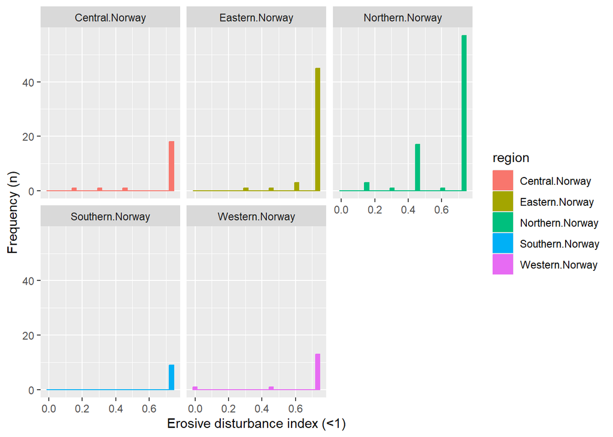

```r
# mountains
res.ANO.slit %>%
  filter(hovedoekosystem_250m2=='fjell' | hovedoekosystem_rute=='Mountain') %>%
  filter(erosion<0.99) %>%
  ggplot( aes(x=erosion, color=region, fill=region)) +
  geom_histogram() +
  xlab("Erosive disturbance index (<1)") +
  ylab("Frequency (n)") +
  facet_wrap(~region)
```

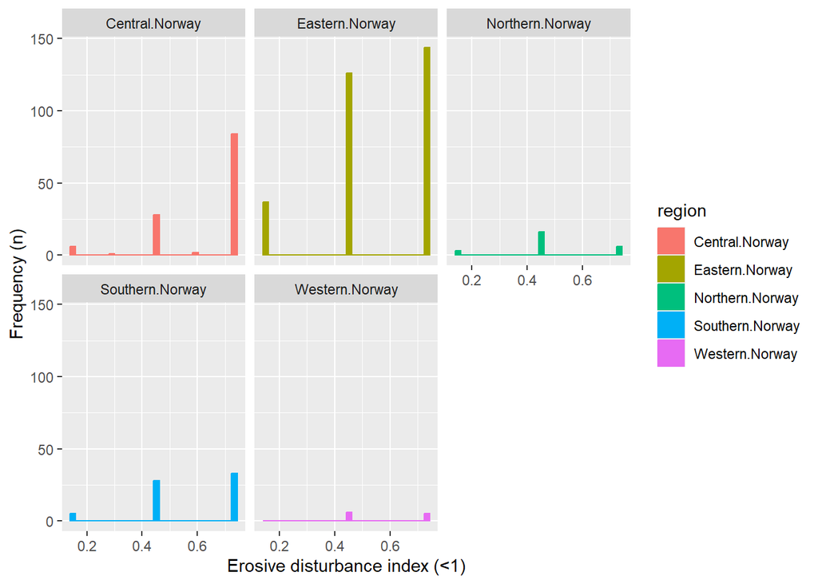

```r
# forests
res.ANO.slit %>%
  filter(hovedoekosystem_250m2=='skog' | hovedoekosystem_rute=='Forest') %>%
  filter(erosion<0.99) %>%
  ggplot( aes(x=erosion, color=region, fill=region)) +
  geom_histogram() +
  xlab("Erosive disturbance index (<1)") +
  ylab("Frequency (n)") +
  facet_wrap(~region)
```

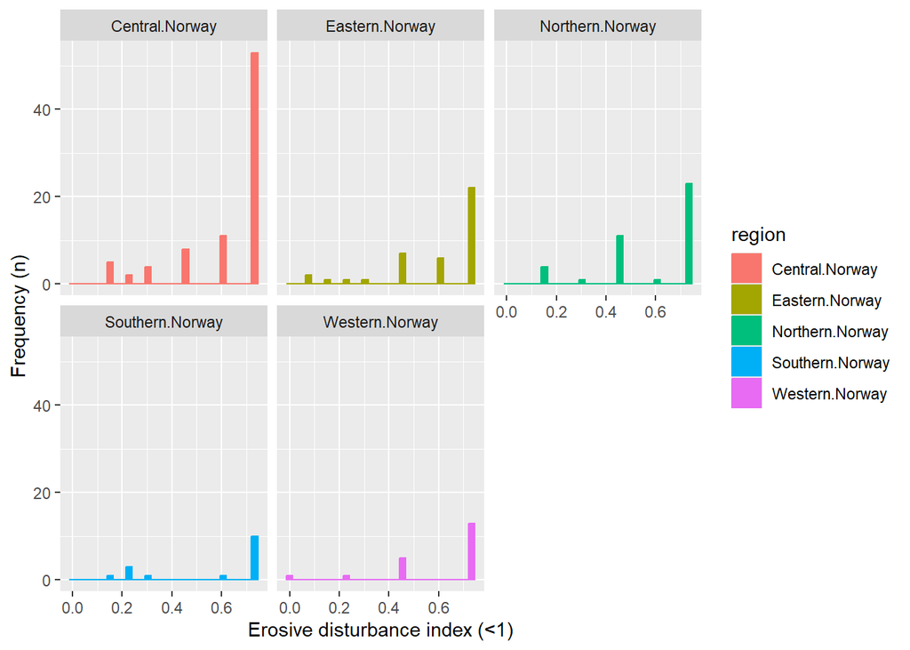

```r
# wetlands
res.ANO.slit %>%
  filter(hovedoekosystem_250m2=='vaatmark' | hovedoekosystem_rute=='Wetland') %>%
  filter(erosion<0.99) %>%
  ggplot( aes(x=erosion, color=region, fill=region)) +
  geom_histogram() +
  xlab("Erosive disturbance index (<1)") +
  ylab("Frequency (n)") +
  facet_wrap(~region)
```

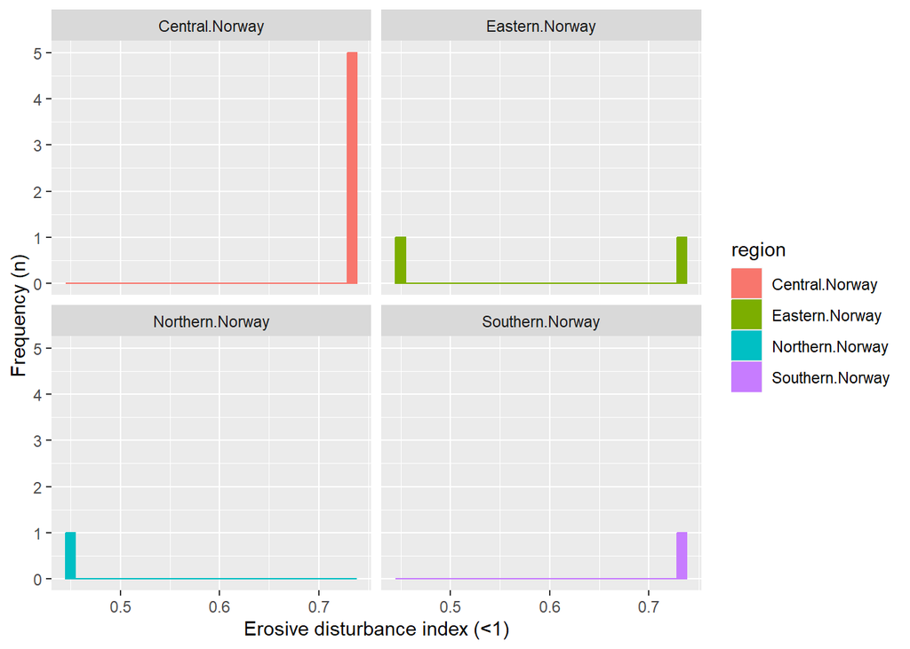

```r
# naturally open lowland
res.ANO.slit %>%
  filter(hovedoekosystem_250m2=='naturlig_apne' | hovedoekosystem_rute=='Natopen') %>%
  filter(erosion<0.99) %>%
  ggplot( aes(x=erosion, color=region, fill=region)) +
  geom_histogram() +
  xlab("Erosive disturbance index (<1)") +
  ylab("Frequency (n)") +
  facet_wrap(~region)
```

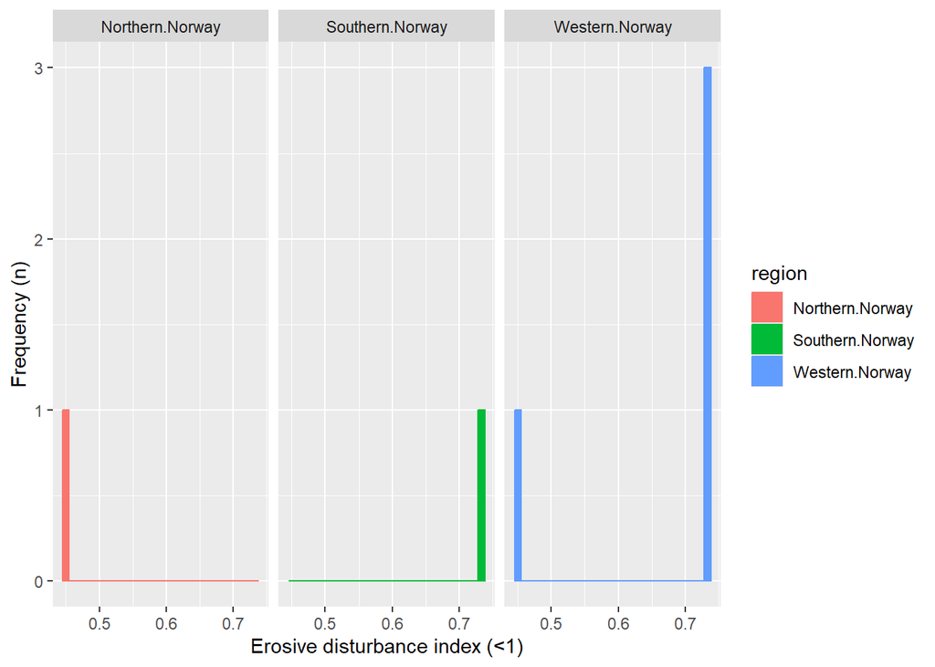

```r
# semi-natural
res.ANO.slit %>%
  filter(hovedoekosystem_250m2=='semi_naturlig_mark' | hovedoekosystem_rute=='Seminat') %>%
  filter(erosion<0.99) %>%
  ggplot( aes(x=erosion, color=region, fill=region)) +
  geom_histogram() +
  xlab("Erosive disturbance index (<1)") +
  ylab("Frequency (n)") +
  facet_wrap(~region)
```

**Session Info**